# HW 5

Liam Middleton

2023-03-29

### The Iris flower data set is a multivariable (multicolumn) data set introduced by the British statistician and biologist Ronald Fisher in his 1936 paper “The use of multiple measurements in taxonomic problems”. It is sometimes called Anderson’s Iris data set because Edgar Anderson collected the data to quantify the morphologic variation of Iris flowers of three related species. The data set consists of 50 samples from each of three species of Iris (Iris Setosa, Iris virginica, and Iris versicolor). Four features were measured from each sample: the length and the width of the sepals and petals, in centimeters.

This dataset became a typical test case for many statistical classification techniques in machine learning.

```r
#adapt this code to your working directory, etc.
setwd("C:/Users/liamm/OneDrive/Documents/DATA 1501/Assignment 5")
iris <- read.csv("C:/Users/liamm/OneDrive/Documents/DATA 1501/Assignment 5/IRIS.csv", header = TRUE, sep = ",")
```

### Problem 1. Display the 5-number summary for each of the numerical variables (columns) in the data set.

(Hint: You may use the summary() function.)

```r
#YOUR CODE GOES HERE
summary(iris)
```

```
##   sepal_length    sepal_width     petal_length    petal_width
##  Min.   :4.300   Min.   :2.000   Min.   :1.000   Min.   :0.100
##  1st Qu.:5.100   1st Qu.:2.800   1st Qu.:1.600   1st Qu.:0.300
##  Median :5.800   Median :3.000   Median :4.350   Median :1.300
##  Mean   :5.843   Mean   :3.054   Mean   :3.759   Mean   :1.199
##  3rd Qu.:6.400   3rd Qu.:3.300   3rd Qu.:5.100   3rd Qu.:1.800
##  Max.   :7.900   Max.   :4.400   Max.   :6.900   Max.   :2.500
##    species
##  Length:150
##  Class :character
##  Mode  :character
##
##
##
```

### Problem 2. Compute the variance and standard deviation for each of the numerical variables (sepal_length, sepal_width, petal_length, and petal_width).

```r
#YOUR CODE GOES HERE
print("this is the variable data")
```

```
## [1] "this is the variable data"
```

```r
var(iris$sepal_length)
```

```
## [1] 0.6856935
```

```r
var(iris$sepal_width)
```

```
## [1] 0.188004
```

```r
var(iris$petal_length)
```

```
## [1] 3.113179
```

```r
var(iris$petal_width)
```

```
## [1] 0.5824143
```

```r
print("this is the standard deviation")
```

```
## [1] "this is the standard deviation"
```

```r
sd(iris$sepal_length)
```

```
## [1] 0.8280661
```

```r
sd(iris$sepal_width)
```

```
## [1] 0.4335943
```

```r
sd(iris$petal_length)
```

```
## [1] 1.76442
```

```r
sd(iris$petal_widthS)
```

```
## [1] NA
```

### Problem 3. Make a boxplot for each of the numerical variables.

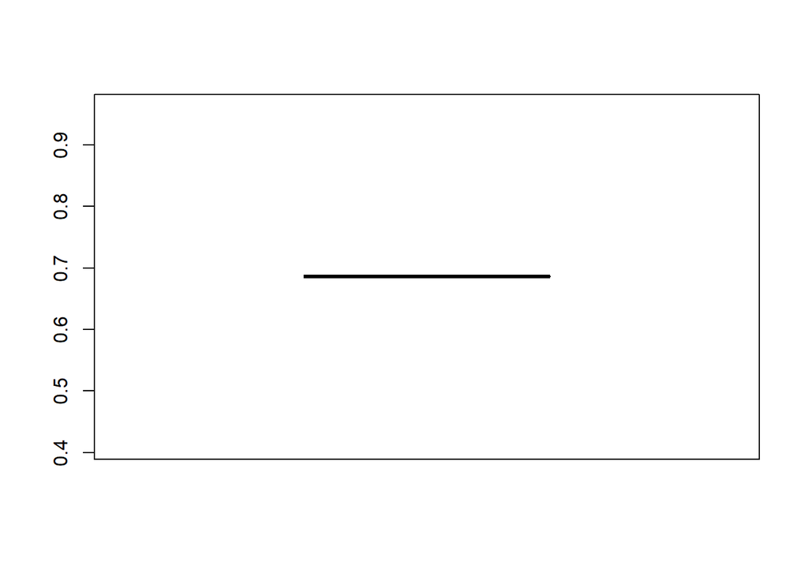

```r
#YOUR CODE GOES HERE
boxplot(var(iris$sepal_length))
```

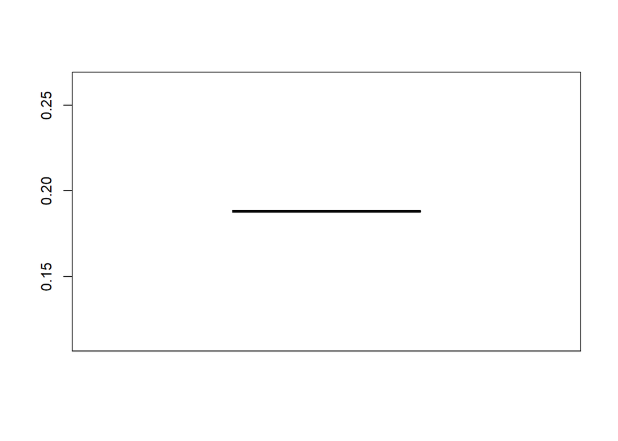

```r
boxplot(var(iris$sepal_width))
```

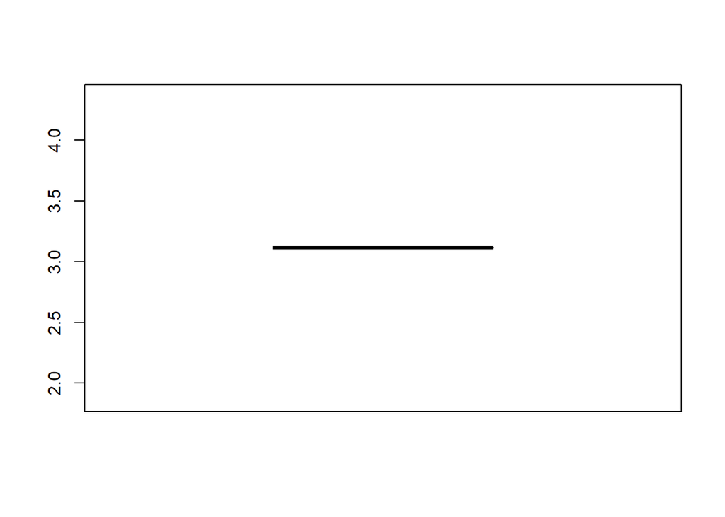

```r
boxplot(var(iris$petal_length))
```

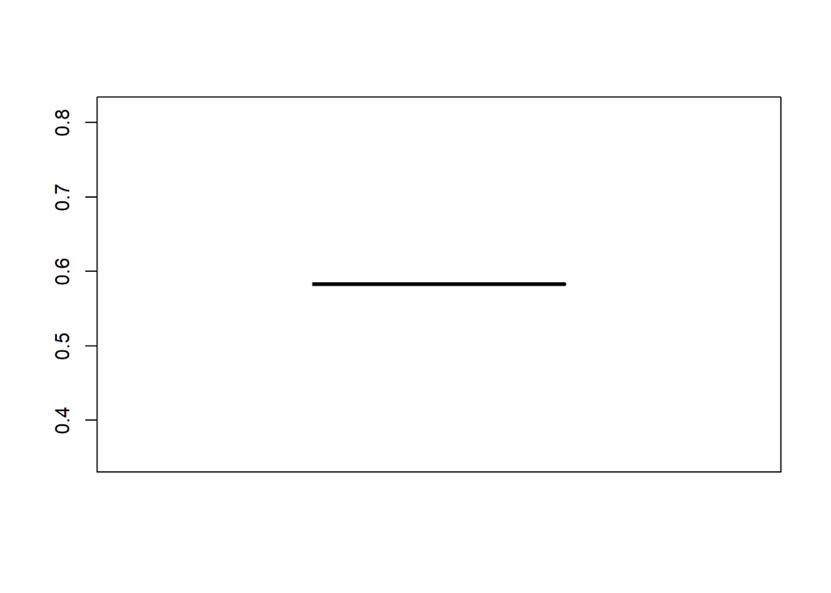

```r
boxplot(var(iris$petal_width))
```

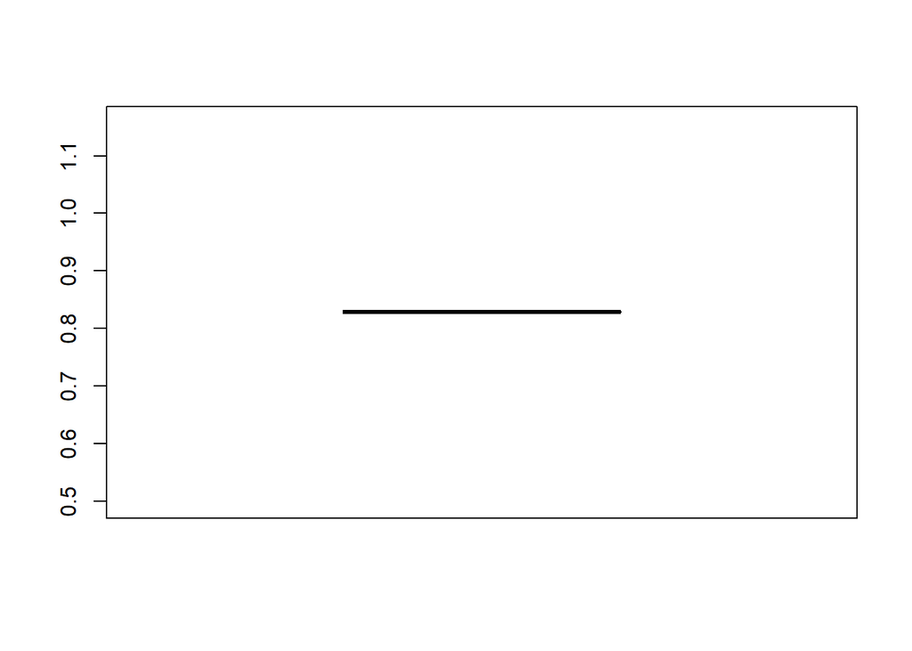

```r
boxplot(sd(iris$sepal_length))
```

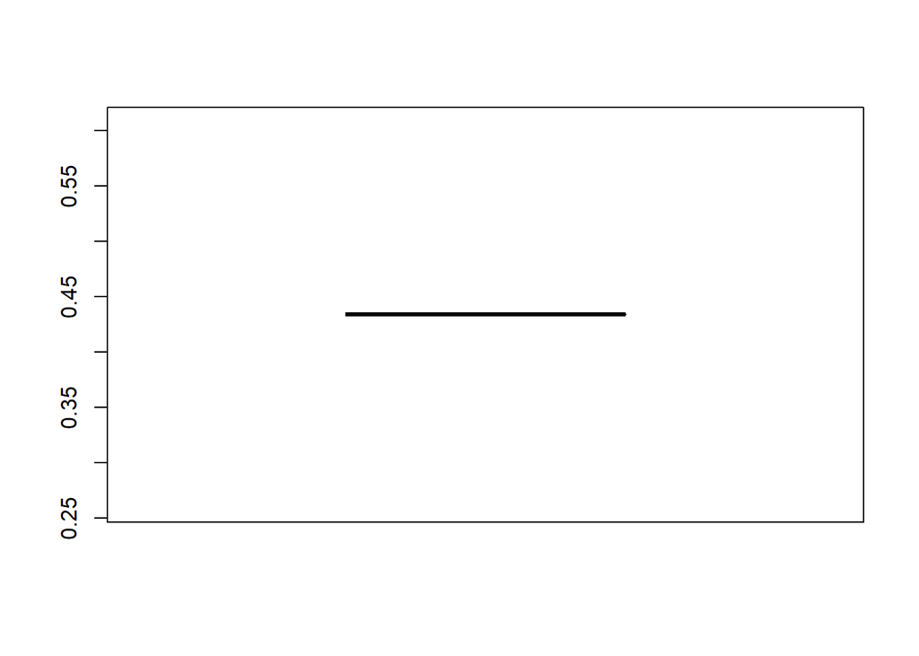

```r
boxplot(sd(iris$sepal_width))
```

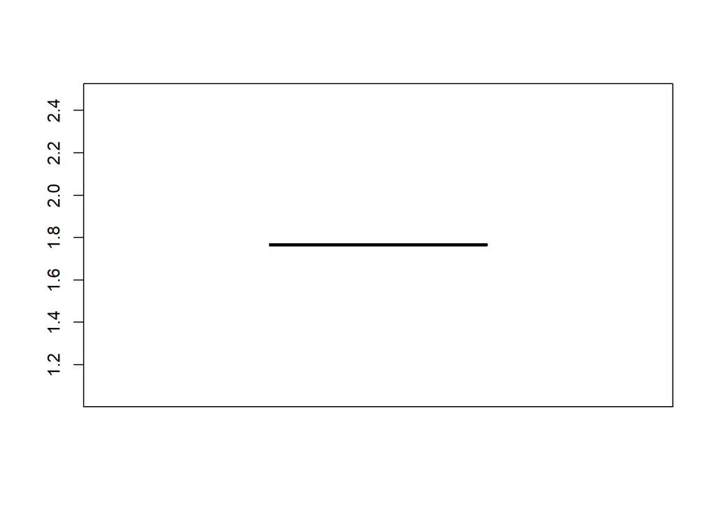

```r
boxplot(sd(iris$petal_length))
```

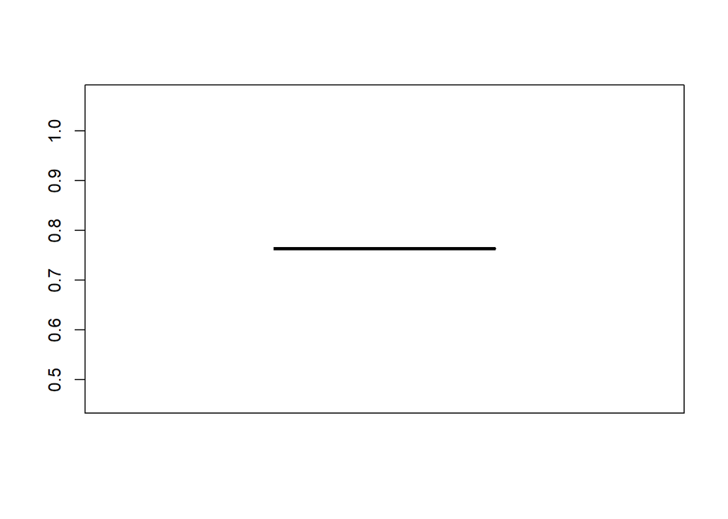

```r
boxplot(sd(iris$petal_width))
```

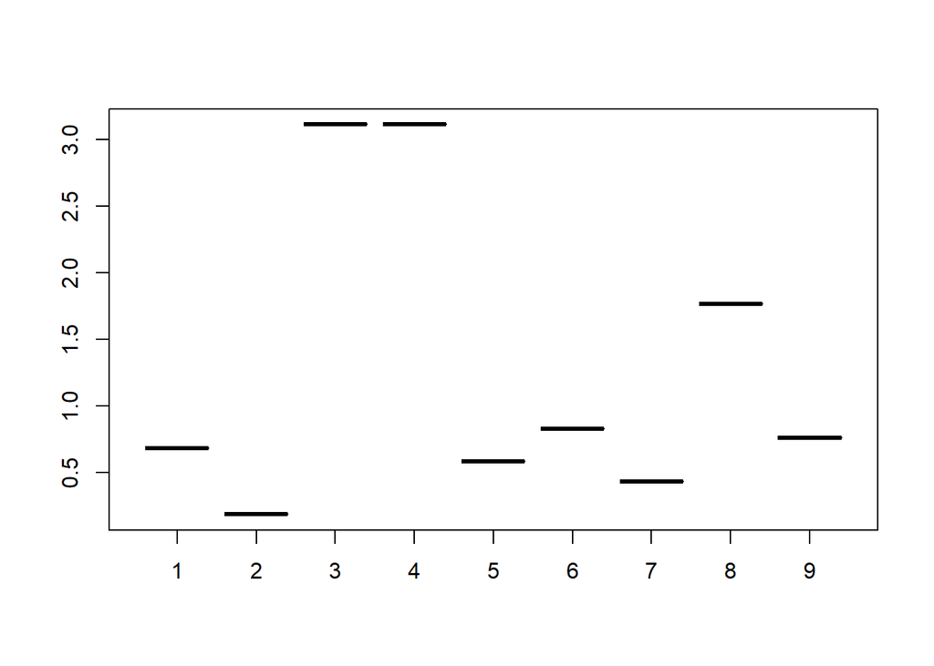

```r
boxplot(var(iris$sepal_length), var(iris$sepal_width), var(iris$petal_length), var(iris$petal_length), var(iris$petal_width),  sd(iris$sepal_length), sd(iris$sepal_width), sd(iris$petal_length), sd(iris$petal_width) )
```